# Trabalho final da disciplina ELT573

# Aluno: Michel Batistin Fiório

## Análise do conjunto de dados BreastCancer

### **Tarefa 1**. Utilize o conjunto ‘BreastCancer’ para realizar análises de reconhecimento de padrões. Para tanto suponha que a variável ‘Class’ (última variável do conjunto) não é conhecida. Faça um relatório. Tal relatório deve ser entregue de maneira organizada discutindo os resultados encontrados.

Na primeira parte do código obtemos o arquivo de dados BreastCancer, avaliamos o conteúdo, limpamos dados faltantes (NA) e convertemos os dados de ‘factor’ para ‘numeric’.

```r
#install.packages("mlbench")
library(mlbench)

# Obter o arquivo de dados
data(BreastCancer)
bc = BreastCancer

# Remover dados NA
bc = na.omit(bc)

# Converter de factor p/ numeric
bc$Cl.thickness = as.numeric(bc$Cl.thickness)
bc$Cell.size = as.numeric(bc$Cell.size)
bc$Cell.shape = as.numeric(bc$Cell.shape)
bc$Marg.adhesion = as.numeric(bc$Marg.adhesion)
bc$Epith.c.size = as.numeric(bc$Epith.c.size)
bc$Bare.nuclei = as.numeric(bc$Bare.nuclei)
bc$Bl.cromatin = as.numeric(bc$Bl.cromatin)
bc$Normal.nucleoli = as.numeric(bc$Normal.nucleoli)
bc$Mitoses = as.numeric(bc$Mitoses)
```

Após tratamento dos dados iniciamos as análises dos componentes principais. Serão realizadas análises utilizando as funções prcomp e PCA para fins de comparação.

Componentes principais com a função ‘prcomp’:

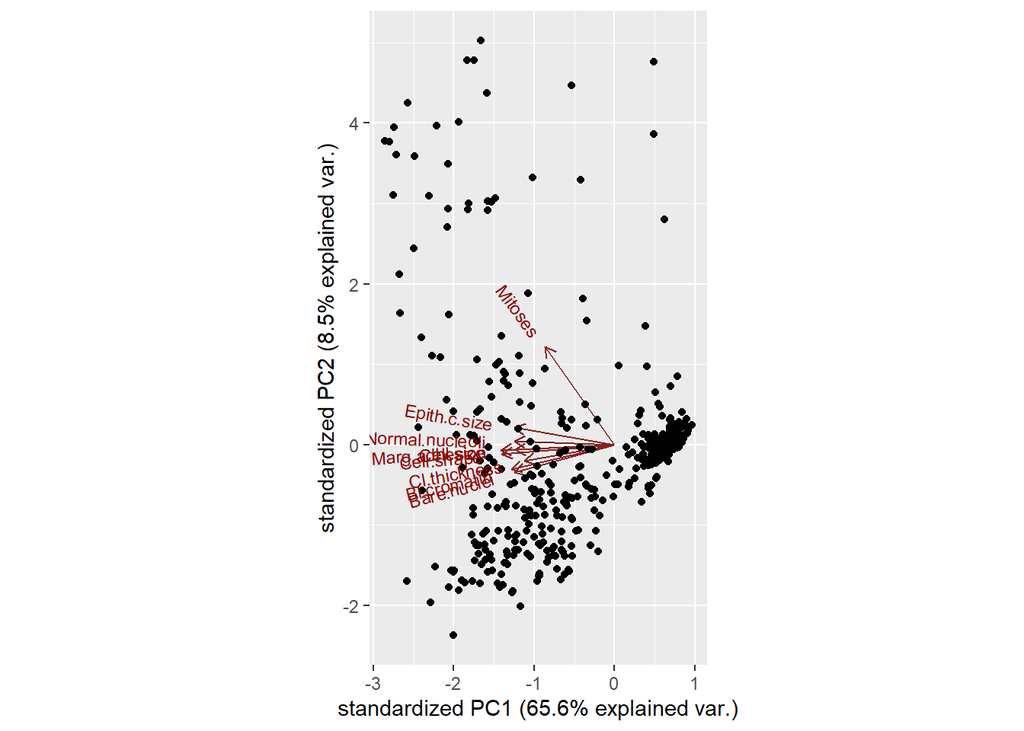

```r
# Análise PCA com função prcomp
bc.pca = prcomp(bc[,2:10], center=TRUE, scale=TRUE)

# Plotando resultado do PCA
library(ggbiplot)
ggbiplot(bc.pca)
```

###### Figura 1: Componentes principais com função ‘prcomp’

Componentes principais com a função ‘PCA’:

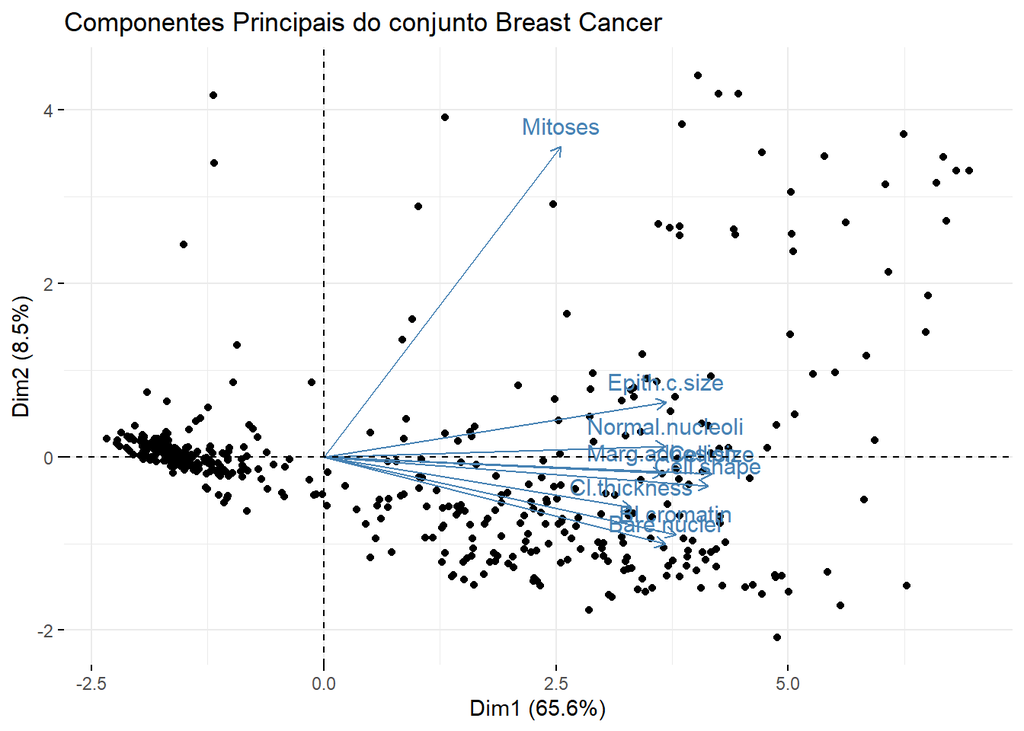

```r
# Análise PCA com função PCA da biblioteca FactoMineR e gráfico da biblioteca

library(FactoMineR)

bc.pca2 = PCA(bc[,2:10], graph = FALSE)

library("factoextra")
fviz_pca(bc.pca2, geom.ind = "point", title = "Componentes Principais do conjunto Breast Cancer")
```

###### Figura 2: Componentes principais com função ‘PCA’

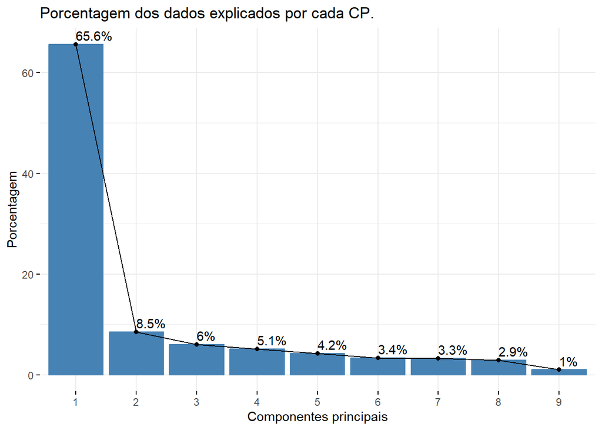

```r
fviz_eig(bc.pca2, addlabels = TRUE, xlab = "Componentes principais", ylab = "Porcentagem" ,title = "Porcentagem dos dados explicados por cada CP.")
```

###### Figura 3: Porcentagem dos dados explicados por cada CP

#### *Análise dos resultados*: O resultado da análise pelas funções ‘prcomp’ e ‘PCA’ foram idênticas, conforme esperado. De acordo com as figuras 1 e 2 acima observamos um agrupamento mais homogêneo de dados em uma metade do gráfico e dados mais espaçados na outra metade. Esse comportamento pode indicar a existência de dois grupos distintos que possuem uma característica em comum entre si.

#### E ao plotar novamente o gráfico da figura 1 adicionando agora os grupos da variável dependente ‘Class’, temos a confirmação da suposição feita acima. Veja figura 4 a seguir.

#### Também pudemos perceber pela figura 3 que os dois primeiros componentes principais explicam 74,1% da variância total dos dados originais.

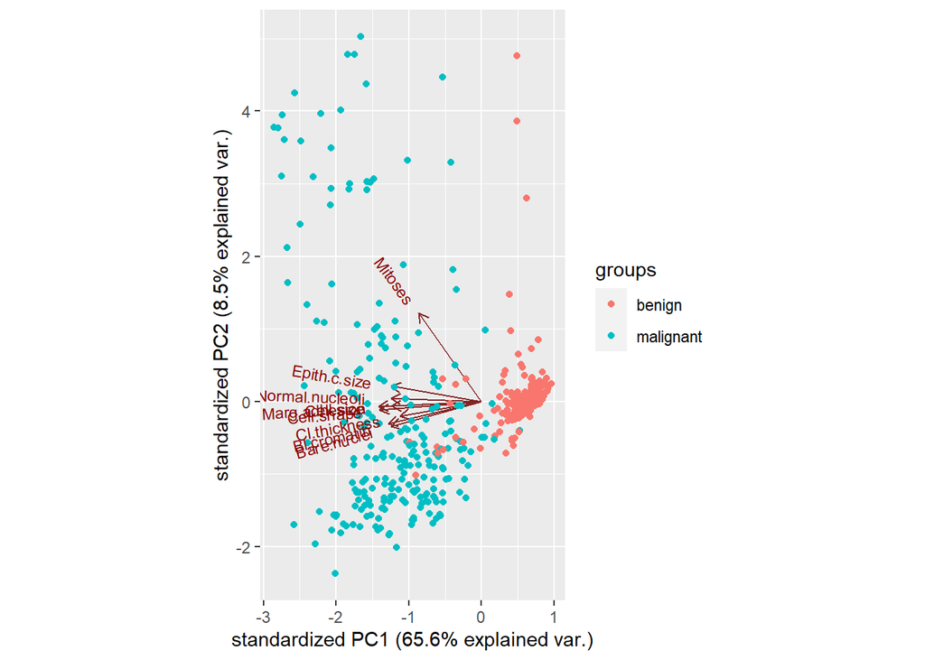

```r
ggbiplot(bc.pca, groups = bc$Class)
```

###### Figura 4: Componentes principais com função ‘prcomp’ e grupos adicionados

Realizaremos agora a análise de agrupamentos do conjunto ‘Breast Cancer’. A análise será feita considerando a distância euclidiana quadrática.

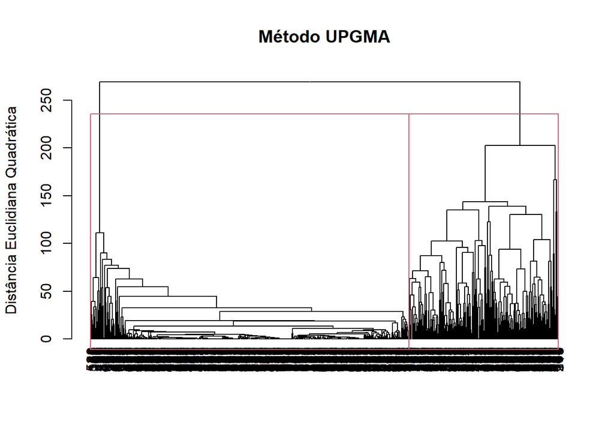

```r
# Distância euclidiana quadrática
dist.bc = dist(bc[,2:10], method = "euclidean")^2

# Criando o dendrograma - agrupamento hierárquico
agrupamento.bc = hclust(dist.bc, method = "average")
dendograma.bc <- as.dendrogram(agrupamento.bc)
plot(dendograma.bc,xlab="",ylab="Distância Euclidiana Quadrática",main="Método UPGMA")
rect.hclust(agrupamento.bc, k = 2)
```

###### Figura 5: Agrupamento do conjunto de dados Breast Cancer, método UPGMA

#### *Análise dos resultados*: A quantidade de amostras presentes no conjunto de dados faz com que o desenho da árvore fique ilegível. Entretanto, isso não impede de observar claramente a existência de dois aglomerados distintos, separados na figura 5 pelos retângulos vermelhos.

### **Tarefa 2**. Utilizando o mesmo conjunto de dados BreastCancer realize análises de classificação. Para tanto, a variável ‘Class’ (última variável do conjunto) é nossa variável dependente. Utilize validação cruzada para avaliar os modelos ajustados. Faça um relatório. Tal relatório deve ser entregue de maneira organizada discutindo os resultados encontrados.

Realizaremos análise do banco de dados Breast Cancer utilizando as técnicas de Análise Discriminante Linear e Análise Discriminante Quadrática. Poderemos verificar qual técnica apresentará modelos com melhores resultados de classificação.

Análise Discriminante Linear:

```r
library(MASS)

discrilinear.bc = lda(Class ~ ., data = bc[,2:11], prior = c(1,1)/2 , CV = TRUE)

# Obter a classificação resultante do modelo para o conjunto de dados

Classif.linear = discrilinear.bc$class
```

```r
# Gerar a matriz de confusão do modelo
confusao.linear = table(bc$Class, Classif.linear)
confusao.linear
```

```
##            Classif.linear
##             benign malignant
##   benign       436         8
##   malignant     18       221
```

```r
# Calculando taxa de erro aparente do modelo

tea.linear = 1 - (sum(diag(confusao.linear))/sum(confusao.linear))
tea.linear
```

```
## [1] 0.03806735
```

Análise discriminante Quadrática:

```r
discriquad.bc = qda(Class ~ ., data = bc[,2:11], CV = TRUE)

# Obter a classificação resultante do modelo para o conjunto de dados

Classif.quad = discriquad.bc$class
```

```r
# Gerar a matriz de confusão do modelo

confusao.quad = table(bc$Class, Classif.quad)
confusao.quad
```

```
##            Classif.quad
##             benign malignant
##   benign       416        28
##   malignant      6       233
```

```r
# Calculando taxa de erro aparente do modelo

tea.quad = 1 - (sum(diag(confusao.quad))/sum(confusao.quad))
tea.quad
```

```
## [1] 0.04978038
```

#### *Análise dos resultados*: realizamos a análise discriminante dos dados no formato linear e quadrático. Utilizamos na geração dos modelos a validação cruzada do tipo ‘leave-one-out’. Foi gerada a matriz de confusão e calculado a taxa de erro aparente dos modelos. Pudemos observar que a taxa de erro foi muito pequena, de apenas 3,8% no modelo da técnica linear e de 4,97% no modelo da técnica quadrática. Portanto o modelo discriminante linear foi mais eficiente na classificação dos dados.

## Análise do conjunto de dados Boston Housing

### **Tarefa 3**. Utilize o conjunto Boston Housing Dataset para predizer o valor médio das casas ocupadas pelo proprietário (medv) por meio de técnicas de predição. Faça um relatório. Tal relatório deve ser entregue de maneira organizada discutindo os resultados encontrados.

```r
# Obtendo e analisando as características do banco de dados
dados.boston = Boston

#Particionar o conjunto de dados (Treinamento e validacao)
set.seed(1)
treinamento.boston = sample (1:nrow(dados.boston), nrow(dados.boston)/2)
```

Modelo utilizando árvore de regressão / random forest com os dados de treinamento:

```r
library(randomForest)
arvore.boston = randomForest(medv ~ .,data=dados.boston , subset=treinamento.boston ,
                      mtry=4, importance =TRUE)
```

Medida de qualidade do modelo acima com os dados de teste. Cálculo da raiz do erro quadrático médio:

```r
predicao.boston = predict(arvore.boston,newdata=dados.boston[-treinamento.boston,])
teste.boston=dados.boston[-treinamento.boston ,"medv"]
REQM_arvore.boston <- sqrt(mean((predicao.boston-teste.boston)^2))
REQM_arvore.boston
```

```
## [1] 4.320301
```

Modelo utilizando técnica de regressão linear múltipla com os dados de treinamento:

```r
regressão.boston = lm(medv ~ ., data = dados.boston, subset = treinamento.boston)
```

Medida de qualidade do modelo acima com os dados de teste. Cálculo da raiz do erro quadrático médio:

```r
predicao.regressão.boston = predict(regressão.boston,newdata=dados.boston[-treinamento.boston,])
REQM_regressão.boston <- sqrt(mean((predicao.regressão.boston-teste.boston)^2))
REQM_regressão.boston
```

```
## [1] 5.182783
```

#### *Análise dos resultados*: Montamos dois modelos diferentes de regressão dos dados Boston Housing utilizando as técnicas de regressão linear múltipla e ramdom forest. OS modelos foram treinados utilizando os dados de treinamento. Para validação do modelo utilizamos os dados de teste e calculamos a eficiência do modelo através do cálculo da raiz do erro quadrático médio(REQM). Os resultados obtidos indicam que o modelo criado pelo random forest ficou ligeiramente melhor ajustado que o modelo de regressão linear.